# R Notebook - Significance Analysis of Cytometry data

N. Pollet

## Importing the data: mean counts of bacteria according to Life Stages of *Xenopus tropicalis* tadpoles.

```r
source("prelude.R")
data_dir<-paste0(data_dir_path,"cytometry")
setwd(data_dir)
cyto<-read.table("Result-dev-mean", header=TRUE)
cyto$ID<-as.factor(cyto$ID)
cyto$Repbio<-as.factor(cyto$Repbio)
summary(cyto)
```

```
##         ID        Repbio   Mean.sample          SD.sample
##  Adulte  :3   repbio1:6   Min.   :   440938   Min.   :       0
##  Juvenile:3   repbio2:6   1st Qu.: 16470955   1st Qu.: 1969068
##  NF45-48 :3   repbio3:6   Median : 36698208   Median : 6728804
##  NF51-54 :3               Mean   :109120285   Mean   :13664077
##  NF56    :3               3rd Qu.: 98643000   3rd Qu.:13756304
##  NF60-61 :3               Max.   :843553242   Max.   :67120009
##   Mean.weight          SD.weight
##  Min.   :5.049e+07   Min.   :        0
##  1st Qu.:3.879e+08   1st Qu.: 32191228
##  Median :1.870e+09   Median :235844967
##  Mean   :2.562e+09   Mean   :214946458
##  3rd Qu.:3.154e+09   3rd Qu.:347835150
##  Max.   :1.164e+10   Max.   :528920478
```

We want to know if the bacterial counts between samples of different developmental stages are identical. The null hypothesis is that the bacterial load during development remains constant, assuming that it follows a normal distribution.

# Kruskal-Wallis test

```r
kruskal.test(Mean.sample ~ ID, data = cyto)
```

```
##
##  Kruskal-Wallis rank sum test
##
## data:  Mean.sample by ID
## Kruskal-Wallis chi-squared = 14.614, df = 5, p-value = 0.01215
```

The p-value is 0.012, hence we can reject the null hypothesis at the 0.05 significance level. There is a significant effect of the developmental stage on the observed counts of bacteria.

# Anova analysis

```r
reg.aov1<-lm(Mean.sample~ID,data=cyto)
anova(reg.aov1)
```

|  | Df | Sum Sq | Mean Sq | F value | Pr(>F) |
| --- | --- | --- | --- | --- | --- |
| ID | 5 | 3.815829e+17 | 7.631658e+16 | 3.305234 | 0.04164864 |
| Residuals | 12 | 2.770754e+17 | 2.308961e+16 | NA | NA |

Using an anova we obtain a P-value of 0.041 , i.e. less than 5% . Thus we reject H0 and can conclude that there is a significant effect of the developmental stage at the 5% threshold. There is at least one developmental stage at which the bacterial load is significantly different from the others. We analysed the residuals to test the normality.

# Analysis of residuals

```r
res.aov1 <-rstudent(reg.aov1)
summary(lm(Mean.sample~ID,data=cyto))
```

```
##
## Call:
## lm(formula = Mean.sample ~ ID, data = cyto)
##
## Residuals:
##        Min         1Q     Median         3Q        Max
## -226413061  -20219432   -4106063    7222837  419016512
##
## Coefficients:
##              Estimate Std. Error t value Pr(>|t|)
## (Intercept)  36252221   87729912   0.413   0.6867
## IDJuvenile  -15319837  124068832  -0.123   0.9038
## IDNF45-48   -34773683  124068832  -0.280   0.7840
## IDNF51-54    18349068  124068832   0.148   0.8849
## IDNF56      388284509  124068832   3.130   0.0087 **
## IDNF60-61    80668328  124068832   0.650   0.5278
## ---
## Signif. codes:  0 '***' 0.001 '**' 0.01 '*' 0.05 '.' 0.1 ' ' 1
##
## Residual standard error: 1.52e+08 on 12 degrees of freedom
## Multiple R-squared:  0.5793, Adjusted R-squared:  0.4041
## F-statistic: 3.305 on 5 and 12 DF,  p-value: 0.04165
```

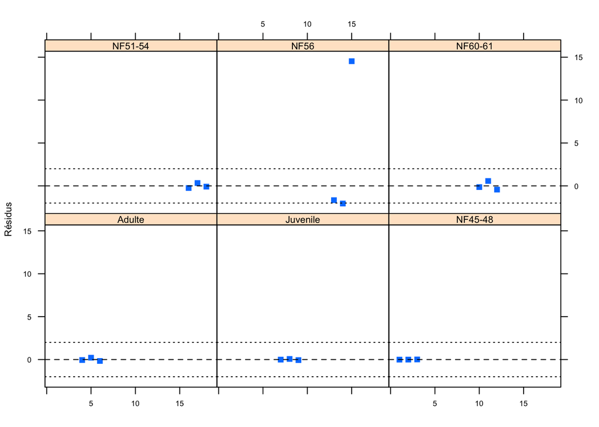

```r
library(lattice)
monpanel <- function(...) {
 panel.xyplot(...)
 panel.abline(h=c(-2,0,2),lty=c(3,2,3),...
 )
 }
trellis.par.set(list(fontsize=list(point=5,text=8)))
xyplot(res.aov1~I(1:18)|ID,data=cyto,pch=15,panel=monpanel,ylab="Résidus",xlab="")
```

# Tukey test

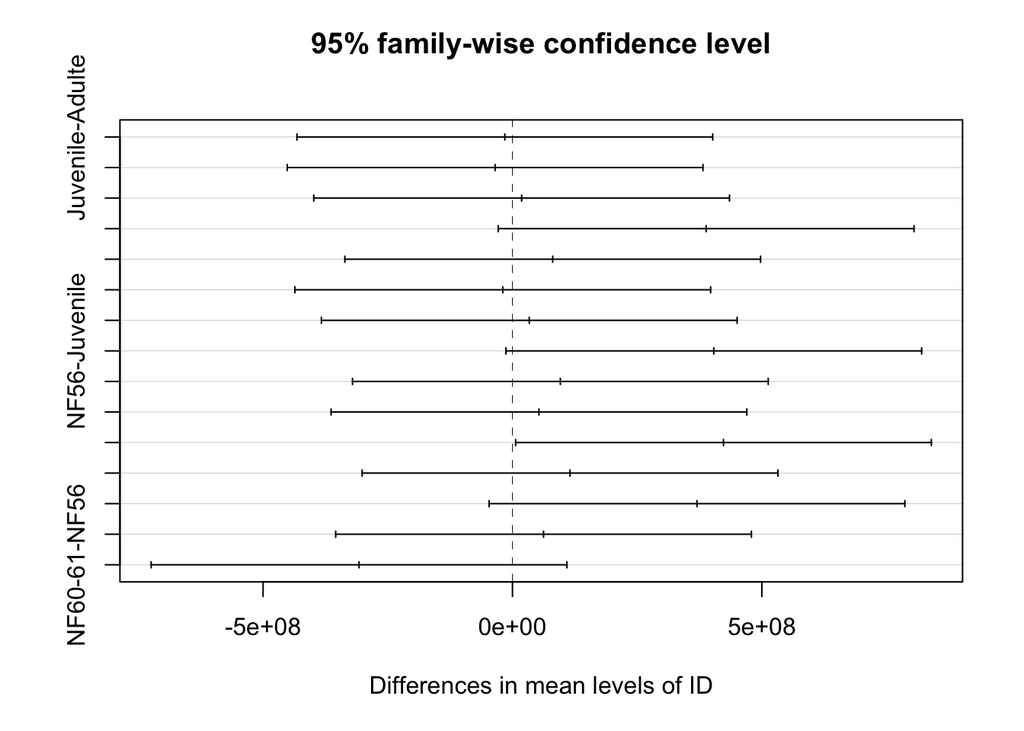

```r
aov.cyto<-aov(Mean.sample~ID,data=cyto)
tuk<- TukeyHSD(aov.cyto)
plot(tuk)
```

```r
pairwise.t.test(cyto$Mean.sample,cyto$ID,p.adj="BH")
```

```
##
##  Pairwise comparisons using t tests with pooled SD
##
## data:  cyto$Mean.sample and cyto$ID
##
##          Adulte Juvenile NF45-48 NF51-54 NF56
## Juvenile 0.904  -        -       -       -
## NF45-48  0.904  0.904    -       -       -
## NF51-54  0.904  0.904    0.904   -       -
## NF56     0.043  0.043    0.043   0.043   -
## NF60-61  0.904  0.904    0.904   0.904   0.087
##
## P value adjustment method: BH
```